# Dustin Johnson

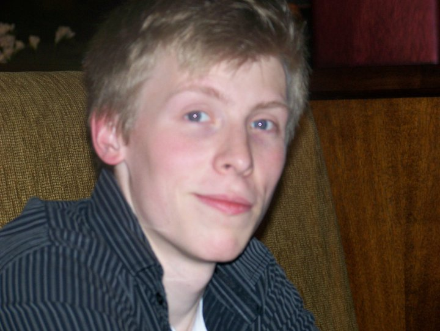

> *“Life is like a game of cards. The hand you are dealt is determinism; the way you play it is free will.”*  
> ~ Jawaharlal Nehru

## About me

I live in Vancouver, Canada, where I’m currently a Researcher in the Department of Statistics and the program manager of the Applied Quantitative Methods (AQM) program at the University of British Columbia, where I earned my degree in Finance and Statistics.

If you asked anyone about me, they’d probably refer to me as the data guy - and for good reason! I am passionate about data science and machine learning and its applications to corporate decision making. My current research consists of high-dimensional functional approximation using Gaussian process ensembles. My experience with statistical consulting and research in computational statistics has provided me with a robust set of skills in designing machine learning algorithms, leveraging high performance computing through parallel programming, and utilising ‘big’ data (>1TB).

## Working Papers

- “A Sub-bagging Approach to Gaussian Process Models for Deterministic Outputs” (Supervised by William Welch)
- “A Benchmarking Comparison of MCMC and SMC Samplers” (with Jason Hartford)
- “Benchmarking Performance of Julia and Python for MCMC” (with Jason Hartford)

## Research Awards and Grants

- National Science and Engineering Research Council (NSERC) of Canada Undergraduate Student Research Award (USRA) - Department of Statistics (2015)
- Teaching and Learning Enhancement Fund (TLEF) for development of the Applied Quantitative Methods (AQM) program developed in 2014, $25,000 (pending)